# Project 1

Author

Libby Brill, Emi Degembe, Alvaro Ramos

Published

April 25, 2026

# Context

## On MMR

Measels is a highly contagious respiratory infection caused by the measels virus. The spread of the virus is often through respiratory droplets and can remain in the air for up to 2 hours. While children are the most commonly affected, those who are unvaccinated, pregnant, or immunocompromised are at an increased risk. Typical symptoms include fever, congestion, cough, red eyes, and rash. Complications have led to hospitalization, pneumonia, or even a brain infection.[^1]

Rubella is also a high contagious viral infection spread through airborne droplets or even direct contact with infected mucus from the nose or throat. Compared to measels, there are similar symptoms, though rubella is most known for its distinct rash pattern. Though Rubella is a mild infection for most, pregnant mothers can pass the infection to their unborn child, which can lead to severe complications. Congenital rubella symptoms include miscarriages, stillbirths, growth delays, deafnes, problems in organ formation includive the heart, or even learning difficulties.[^2]

Both do not have treatments so if infected, the patient must let the virus run its course. The most common prevention method is through the Measels-Mumps-Rubella (MMR) vaccine which is often given to children between 12-15 months and again between 4-6 years old. This vaccine protects against the three viral infections for life and can prevent Rubella during pregnancies.[^3]

## On Data Collection

The data comes from the World Health Organization’s Provisional monthly measels and rubella data, which contains information on those who were suspected to have the virus, were tested for the virus, and confirmed had the virus. The data includes cases from as early as 2012 and as recent as 2025, collected globally by the organization. The measels case testing follows the WHO’s [Measles Programmatic Risk Assessment Tool](https://www.who.int/teams/immunization-vaccines-and-biologicals/immunization-analysis-and-insights/surveillance/measles-programmatic-risk-assessment-tool) where they further collect samples as necessary. The table below breaks down each identified case method following the assessment of a suspected case:

[output not shown]

# Data Cleaning

# Preliminary Summary Statistics

Below presents a series of tables which provide summary statistics on various columns described in the dataset.

```r
tuesdata <- tidytuesdayR::tt_load('2025-06-24')

cases_month <- tuesdata$cases_month
cases_year <- tuesdata$cases_year
```

```r
########## HELPER FUNCTIONS ##########
######################################

# using the same summ_stats as practice activity 2
summ_stats <- function(x) {

    # if x contains numeric values
      # return a tibble with the mean, med, sd, IQR, and n observed
    if (is.numeric(x)) {
        out_df <- tibble(
            mean = mean(x, na.rm = TRUE),
            median = median(x, na.rm = TRUE),
            stdev = sd(x, na.rm = TRUE),
            iqr = IQR(x, na.rm = TRUE),
            n = sum(!is.na(x)) # length won't work bc of NAs
        )
    # if x contains categorical, return tibble with # of levels in variable
    } else if (is.factor(x) || is.character(x)) {
        out_df <- tibble(
            n_levels = n_distinct(x)
        )
    } else {
        stop("Inputted values are not numeric or categorical.")
    }

    #return the data frame.
    out_df
}

summarize_stats <- function(df, col = measles_lab_confirmed, mode = region) {
  ######### PARAMETERS ##########
  # input: df -- the dataframe of interest
  # col: column of interest to summarize by:
  #   measels_suspect,
  #   measels_clinical,
  #   measels_epi_linked,
  #   measels_lab_confirmed [DEFAULT],
  #   measels_total
  # mode: aggregate by options:
  #   region [DEFAULT],
  #   country,
  #   iso3,
  #   year
  ###############################

  df |>
    select({{mode}}, {{col}}) |>
    group_by({{mode}}) |>
    #group_map removed the group column, so to retain that, group_modify.
    # See second example: https://dplyr.tidyverse.org/reference/group_map.html
    group_modify( ~ summ_stats(.x |>
                              pull({{col}}))) |>
    bind_rows()
}
```

```r
calculate_2024_prop_sc <- function(input_month) {
  if (!is.numeric(input_month)) {
    stop("Months should be integers (1 for Jan, 2 for Feb, etc.)")
  }

  cases_month |>
    filter(year == 2024,
           month == input_month) |>
    summarize(symptomatic = sum(measles_suspect + measles_clinical,
                                na.rm = TRUE),
              confirmed = sum(measles_epi_linked + measles_lab_confirmed,
                              na.rm = TRUE),
              prop = symptomatic / confirmed) |>
    select(prop) |>
    pull()
}
```

```r
dy <- cases_year |>
  # recoding region to be more informative
  mutate(region = fct_recode(
    region,
    "Africa" = "AFRO",
    "Americas" = "AMRO",
    "Eastern Mediterranean" = "EMRO",
    "Europe" = "EURO",
    "South East Asia" = "SEARO",
    "Western Pacific" = "WPRO"
    )
    )
```

## Summary of Existing Variables

```r
dy |>

  # used to assign each country to the appropriate region when merging
  select(region, country) |>
  unique() |>
  arrange(country) |>

  full_join(summarize_stats(dy, measles_total, country)) |>
  group_by(region) |>
  arrange(-mean) |>

  gt() |>
  fmt_number(columns = -c(country, region, n),
             decimals = 2) |>
  cols_label("country" = "Country",
             "mean" = "Mean",
             "median" = "Median",
             "stdev" = "Standard Deviation",
             "iqr" = "IQR",
             "n" = "Sample Size",
             ) |>
  tab_style(
    style = cell_text(weight = "bold"),
    locations = cells_column_labels()
    ) |>
  tab_style(
    style = cell_text(style = "italic", decorate = "underline"),
    locations = cells_row_groups()
    ) |>
  tab_header(
    title = md("Summary Statistics of Total Measles Cases by Country")
  ) |>
  tab_caption(
    caption = md("**Table 1** Summary table visualizing various statistics of
                 total measles cases by country. Samples are collected annually
                 from 2012 to 2024. Notably, some countries demonstrate large
                 differences between the mean and median.")
    )
```

Summary Statistics of Total Measles Cases by Country

| Country | Mean | Median | Standard Deviation | IQR | Sample Size |
| --- | --- | --- | --- | --- | --- |
| South East Asia |  |  |  |  |  |
| India | 39,543.75 | 32,179.50 | 30,937.75 | 58,948.75 | 12 |
| Indonesia | 5,949.00 | 4,614.50 | 5,712.30 | 5,962.75 | 14 |
| Thailand | 2,135.36 | 892.00 | 2,513.54 | 3,143.50 | 14 |
| Bangladesh | 1,408.14 | 361.50 | 1,683.69 | 2,089.75 | 14 |
| Myanmar | 965.08 | 276.00 | 1,519.05 | 1,265.50 | 12 |
| Sri Lanka | 658.36 | 55.00 | 1,130.34 | 705.00 | 14 |
| Nepal | 287.64 | 201.50 | 258.27 | 248.00 | 14 |
| Timor-Leste | 11.00 | 7.50 | 14.56 | 9.75 | 14 |
| Bhutan | 9.38 | 4.00 | 18.93 | 10.00 | 13 |
| Maldives | 2.00 | 0.00 | 4.64 | 1.00 | 14 |
| Democratic People's Republic of Korea | 0.57 | 0.00 | 2.14 | 0.00 | 14 |
| Africa |  |  |  |  |  |
| Madagascar | 16,139.07 | 72.50 | 56,834.29 | 78.25 | 14 |
| Nigeria | 15,005.21 | 11,068.00 | 13,442.85 | 8,584.00 | 14 |
| Ethiopia | 8,416.07 | 4,692.00 | 8,361.56 | 10,401.25 | 14 |
| Democratic Republic of the Congo | 6,013.14 | 4,696.50 | 5,047.68 | 2,611.75 | 14 |
| Angola | 2,630.77 | 1,084.00 | 3,469.82 | 2,976.00 | 13 |
| Cameroon | 1,601.50 | 850.00 | 1,542.11 | 1,000.25 | 14 |
| Burkina Faso | 1,260.00 | 747.00 | 1,823.06 | 1,065.25 | 14 |
| Liberia | 1,252.21 | 446.00 | 1,697.12 | 1,553.50 | 14 |
| Niger | 1,050.57 | 789.00 | 623.03 | 684.00 | 14 |
| Côte d'Ivoire | 992.71 | 490.00 | 1,712.70 | 1,111.25 | 14 |
| South Sudan | 889.67 | 517.00 | 883.76 | 964.00 | 12 |
| Ghana | 854.64 | 334.50 | 1,158.61 | 982.25 | 14 |
| Chad | 810.57 | 605.50 | 703.65 | 1,012.25 | 14 |
| Uganda | 654.36 | 463.00 | 641.16 | 535.00 | 14 |
| Central African Republic | 610.57 | 174.00 | 985.37 | 307.25 | 14 |
| Kenya | 574.64 | 326.50 | 636.88 | 601.75 | 14 |
| United Republic of Tanzania | 557.71 | 493.00 | 375.00 | 487.25 | 14 |

[output cut: 170 more lines]

```r
dy |>

  # used to assign each country to the appropriate region when merging
  select(region, country) |>
  unique() |>
  arrange(country) |>

  full_join(summarize_stats(dy,
                            measles_incidence_rate_per_1000000_total_population,
                            country)) |>
  group_by(region) |>
  slice_max(mean, n = 5) |>
  arrange(-mean) |>
  gt() |>
  fmt_number(columns = -c(country, region, n),
             decimals = 2) |>
  cols_label("country" = "Country",
             "mean" = "Mean",
             "median" = "Median",
             "stdev" = "Standard Deviation",
             "iqr" = "IQR",
             "n" = "Sample Size",
             ) |>
  tab_style(
    style = cell_text(weight = "bold"),
    locations = cells_column_labels()
    ) |>
  tab_style(
    style = cell_text(style = "italic", decorate = "underline"),
    locations = cells_row_groups()
    ) |>
  tab_header(
    title = md("Summary Statistics for Total Number of Measles Cases for Each
               1 Million Individuals")
  ) |>
  tab_caption(
    caption = md("**Table 2** Summary table visualizing various statistics of
                 the number total measles cases for each 1 million individuals.
                 Samples are collected annually from 2012 to 2024 for each
                 country. Notably, some countries demonstrate large differences
                 between the mean and median.")
    )
```

Summary Statistics for Total Number of Measles Cases for Each 1 Million Individuals

| Country | Mean | Median | Standard Deviation | IQR | Sample Size |
| --- | --- | --- | --- | --- | --- |
| Western Pacific |  |  |  |  |  |
| Mongolia | 1,188.58 | 0.16 | 3,005.82 | 3.31 | 14 |
| Micronesia (Federated States of) | 268.86 | 0.00 | 1,005.97 | 0.00 | 14 |
| Tonga | 160.88 | 160.88 | 227.52 | 160.88 | 2 |
| Solomon Islands | 121.45 | 0.00 | 437.89 | 0.00 | 13 |
| Philippines | 99.68 | 23.66 | 169.05 | 28.22 | 14 |
| Europe |  |  |  |  |  |
| Kyrgyzstan | 619.84 | 80.69 | 982.27 | 879.31 | 14 |
| Georgia | 357.28 | 58.48 | 598.81 | 485.72 | 14 |
| Romania | 261.76 | 105.94 | 423.13 | 306.47 | 14 |
| Kazakhstan | 238.50 | 24.11 | 409.67 | 166.95 | 14 |
| Ukraine | 217.18 | 26.04 | 435.00 | 94.67 | 14 |
| Africa |  |  |  |  |  |
| Madagascar | 572.83 | 2.79 | 2,013.91 | 2.91 | 14 |
| Liberia | 237.17 | 90.13 | 311.58 | 304.95 | 14 |
| Equatorial Guinea | 184.97 | 24.51 | 350.79 | 112.40 | 14 |
| Gabon | 170.06 | 21.30 | 256.53 | 359.19 | 14 |
| Central African Republic | 123.73 | 37.02 | 195.00 | 60.32 | 14 |
| Eastern Mediterranean |  |  |  |  |  |
| Yemen | 307.80 | 106.69 | 373.70 | 510.64 | 14 |
| Somalia | 303.66 | 88.38 | 456.25 | 304.53 | 14 |
| NA | 114.81 | 114.81 | 96.51 | 68.25 | 2 |
| Afghanistan | 82.36 | 48.56 | 101.67 | 70.18 | 14 |
| Iraq | 80.53 | 10.23 | 188.37 | 36.25 | 14 |
| South East Asia |  |  |  |  |  |
| Thailand | 30.80 | 15.85 | 34.78 | 44.44 | 14 |
| Sri Lanka | 30.36 | 2.54 | 52.66 | 30.64 | 14 |
| India | 29.58 | 22.45 | 22.55 | 36.69 | 12 |
| Indonesia | 22.87 | 17.34 | 20.87 | 21.80 | 14 |
| Myanmar | 18.64 | 5.25 | 29.02 | 24.34 | 12 |
| Americas |  |  |  |  |  |
| Venezuela (Bolivarian Republic of) | 23.61 | 0.00 | 60.48 | 14.21 | 10 |
| Brazil | 16.61 | 0.63 | 31.63 | 12.74 | 12 |
| Canada | 14.38 | 1.11 | 38.97 | 4.10 | 11 |
| Belize | 3.61 | 0.00 | 11.98 | 0.00 | 11 |
| Mexico | 3.35 | 0.01 | 10.52 | 0.10 | 11 |

## Summary of Created Variables

```r
cases_month |>
  filter(year == 2024) |>
  distinct(month) |>
  mutate(prop_symptomatic_confirmed = map_dbl(month, calculate_2024_prop_sc),
         month = month(month, label = TRUE, abbr = FALSE)) |>
  gt() |>
  data_color(columns = prop_symptomatic_confirmed, method = "numeric",
             palette = "Greens") |>
  fmt_number(columns = prop_symptomatic_confirmed, decimals = 2) |>
  cols_align(align = "left", columns = month) |>
  tab_style(style = cell_text(weight = "bold"),
            locations = cells_column_labels()) |>
  tab_header(title = md("2024 Ratios of Symptomatic to Confirmed Measles Cases")) |>
  tab_caption(caption = md("**Table 3** Summary table visualizing how overall
                           (across all countries) ratios of symptomatic to
                           confirmed measles cases changed throughout the year
                           2024")) |>
  cols_label(month = "Month",
             prop_symptomatic_confirmed = "Symptomatic/Confirmed Proportion")
```

**Table 3** Summary table visualizing how overall (across all countries) ratios of symptomatic to confirmed measles cases changed throughout the year 2024

2024 Ratios of Symptomatic to Confirmed Measles Cases

| Month | Symptomatic/Confirmed Proportion |
| --- | --- |
| January | 2.18 |
| February | 2.46 |
| March | 2.63 |
| April | 2.84 |
| May | 3.10 |
| June | 3.21 |
| July | 3.83 |
| August | 5.00 |
| September | 5.70 |
| October | 6.08 |
| November | 4.92 |
| December | 4.00 |

```r
cases_year_modified <- dy |>
  mutate(p_lab_total = measles_lab_confirmed / measles_total)

summarize_stats(cases_year_modified, col = p_lab_total) |>
  arrange(-mean) |>
  ungroup() |>
  gt() |>
  fmt_number(columns = -c(region, n),
              decimals = 2) |>
  cols_align(align = "left", columns = region) |>
  cols_label("region" = "Region",
              "mean" = "Mean",
              "median" = "Median",
              "stdev" = "Standard Deviation",
              "iqr" = "IQR",
              "n" = "Sample Size",
              ) |>
  tab_style(
    style = cell_text(weight = "bold"),
    locations = cells_column_labels()
    ) |>
  tab_style(
    style = cell_text(style = "italic", decorate = "underline"),
    locations = cells_row_groups()
    ) |>
  tab_header(
    title = md("Summary Statistics for Proportion of Lab Confirmed Measles Cases
               by Region")
  ) |>
  tab_caption(
    caption = md("**Table 4** Summary table for the proportion of total measles
                 cases that are lab confirmed. Samples are collected annually
                 from a year range of 2012-2024.")
    )
```

**Table 4** Summary table for the proportion of total measles cases that are lab confirmed. Samples are collected annually from a year range of 2012-2024.

Summary Statistics for Proportion of Lab Confirmed Measles Cases by Region

| Region | Mean | Median | Standard Deviation | IQR | Sample Size |
| --- | --- | --- | --- | --- | --- |
| Americas | 0.95 | 1.00 | 0.16 | 0.00 | 77 |
| Europe | 0.80 | 0.94 | 0.28 | 0.31 | 546 |
| Western Pacific | 0.74 | 0.91 | 0.33 | 0.43 | 181 |
| Eastern Mediterranean | 0.72 | 0.91 | 0.35 | 0.49 | 278 |
| Africa | 0.50 | 0.47 | 0.35 | 0.71 | 563 |
| South East Asia | 0.48 | 0.48 | 0.32 | 0.53 | 118 |

# Additional Data Sources

## API-Pulled Data – International Monetary Fund

The International Monetary Fund is an international financial institution of the United Nations. The organization provides policy advice, financial assistance, and capacity development to its 191 member countries, and therefore collects financial data in order to perform necessary research. We are specifically focused on GDP per capita for each country, for which information has been recorded from 1980 to present day. The API link for the data that is displayed on the website can be found [here](https://www.imf.org/external/datamapper/api/v1/NGDPDPC).

```r
# API call
data <- GET("https://www.imf.org/external/datamapper/api/v1/NGDPDPC")
```

```r
# creating function to make tibbles for each country from json data
country_values <- function(country){

  tibble(json = list(parse_json(data))) |>
    unnest_wider(json) |>
    unnest_longer(values) |>
    unnest_wider(values) |>
    slice_head() |>
    select({{country}}) |>
    unnest_longer({{country}}) |>
    rename(year = str_glue("{country}_id")) |>
    pivot_longer(cols = {{country}},
                 names_to = "iso3",
                 values_to = "GDP_per_capita"
                 ) |>
    mutate(year = as.numeric(year))

}

# storing countries available in both the cases_year dataset and json data
ids <- dy$iso3 |>
  as.factor() |>
  levels()

ids <- ids[ids %in% (
  tibble(json = list(parse_json(data))) |>
    unnest_wider(json) |>
    unnest_longer(values) |>
    unnest_wider(values) |>
    slice_head() |>
    names()
  )]

# creating dataset from json data for each country and merging to one
dv <- map(.x = ids,
          .f = country_values
          ) |>
  bind_rows()

dataset <- cases_year_modified |>
  # join to cases_year dataset MODIFIED TO cases_year_modified to include all data
  full_join(dv) |>
  filter(year >= 2012) #|>
  #mutate(region_info = fct_recode(
    #region,
    #"Africa" = "AFRO",
    #"Americas" = "AMRO",
    #"Eastern Mediterranean" = "EMRO",
    #"Europe" = "EURO",
    #"South East Asia" = "SEARO",
    #"Western Pacific" = "WPRO"
    #)
    #)
```

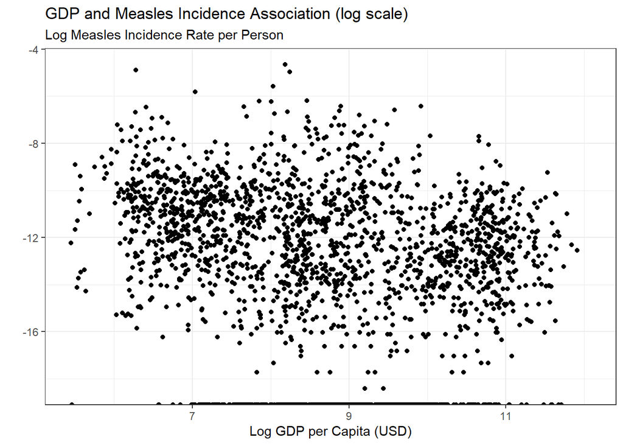

```r
dataset |>
  ggplot(aes(x = log(GDP_per_capita),
             y = log(measles_incidence_rate_per_1000000_total_population/1000000))) +
  geom_point() +
  labs(title = "GDP and Measles Incidence Association (log scale)",
       subtitle = "Log Measles Incidence Rate per Person",
       x = "Log GDP per Capita (USD)",
       y = "") +
  theme_bw()
```

## API-Pulled Data – Measles Containing Vaccine Dose 2

The World Health Organization has recorded the estimated immunization coverage for each year based on various sources from 2003-2024. This estimated coverage is defined as the percentage of children who have received both doses of the measles containing vaccine (MCV2) in a given year, based on the recommended schedule for that nation. More information on the method of estimation is outlined in the Metadata section of the website, but these estimations are useful indicators in tracking the disease reduction efforts. The API link for the data that is displayed on the website can be found [here](https://ghoapi.azureedge.net/api/MCV2).

```r
data <- GET("https://ghoapi.azureedge.net/api/MCV2")

d <- tibble(json = list(parse_json(data))) |>
  unnest_wider(json) |>
  unnest_wider(value, names_sep = "_") |>
  select(-"@odata.context")
```

```r
row <- function(v){
  d |>
    select(v) |>
    unnest_wider(v) |>
    select(ParentLocationCode,
           #ParentLocation,
           SpatialDim,
           TimeDim,
           #Value,
           NumericValue
           )
}
```

```r
data <- map(.x = d |> names(),
            .f = row
            ) |>
  bind_rows() |>
  rename(
    "region" = ParentLocationCode,
    #"region_info" = ParentLocation,
    "iso3" = SpatialDim,
    "year" = TimeDim,
    #value = Value,
    "mcv2" = NumericValue
  )
```

## Joining both sources to create one metadataset

```r
metadata <- dataset |>
  # join to cases_year dataset
  full_join(data |> select(-region),
            by = join_by(iso3, year)
            ) |>
  filter(year >= 2012) |>
  mutate(mcv2 = mcv2 / 100)

colnames(metadata)
```

```
 [1] "region"
 [2] "country"
 [3] "iso3"
 [4] "year"
 [5] "total_population"
 [6] "annualized_population_most_recent_year_only"
 [7] "total_suspected_measles_rubella_cases"
 [8] "measles_total"
 [9] "measles_lab_confirmed"
[10] "measles_epi_linked"
[11] "measles_clinical"
[12] "measles_incidence_rate_per_1000000_total_population"
[13] "rubella_total"
[14] "rubella_lab_confirmed"
[15] "rubella_epi_linked"
[16] "rubella_clinical"
[17] "rubella_incidence_rate_per_1000000_total_population"
[18] "discarded_cases"
[19] "discarded_non_measles_rubella_cases_per_100000_total_population"
[20] "p_lab_total"
[21] "GDP_per_capita"
[22] "mcv2"
```

When looking at `colnames()` of metadata:

- columns 1-20 are from TidyTuesday including created column `p_lab_total`.
- column 21 is from 1st API external data
- column 22 is from 2nd API external data

## Visualization of MCV2

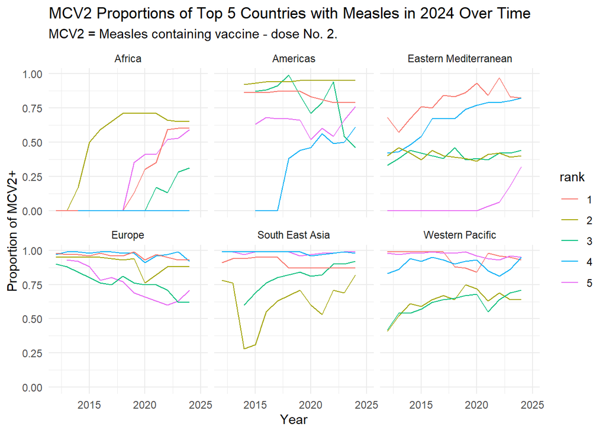

```r
# selecting the top 5 countries with the highest measles cases in 2024
top5 <- metadata |>
  filter(year == 2024 & !is.na(region)) |>
  group_by(region) |>
  mutate(prop_measles = measles_total/total_population) |>
  slice_max(order_by = prop_measles, n = 5) |>
  arrange(desc(prop_measles)) |>
  mutate(rank = as.factor(row_number())) |>
  ungroup() |>
  arrange(region) |>
  select("country", "region", "rank")

metadata |>
  left_join(top5, by = c("region", "country")) |>
  select("country", "region", "year", "mcv2", "rank") |>
  filter(!is.na(region) & !is.na(rank)) |>
  ggplot(aes(x = year, y = mcv2, group = country, color = rank)) +
  geom_line() +
  facet_wrap(~ region) +
  labs(
    title = "MCV2 Proportions of Top 5 Countries with Measles in 2024 Over Time",
    subtitle = "MCV2 = Measles containing vaccine - dose No. 2.",
    x = "Year",
    y = "Proportion of MCV2+"
  ) +
  theme_minimal()
```

# Research Question

## Statistical Model

```r
m <- gls(measles_incidence_rate_per_1000000_total_population ~ region + GDP_per_capita + mcv2,
    data = metadata,
    na.action = na.omit,
    correlation = corAR1(form = ~ year | region / country)
    )

summary(m)$tTable |>
  as_tibble(rownames = "var") |>
  mutate(region = c("Quantitative",
                    "Region (Africa as baseline)",
                    "Region (Africa as baseline)",
                    "Region (Africa as baseline)",
                    "Region (Africa as baseline)",
                    "Region (Africa as baseline)",
                    "Quantitative",
                    "Quantitative"
                    )
         ) |>
  mutate(var = var |>
           str_remove("region") |>
           str_replace("GDP_per_capita", "GDP per capita ($)") |>
           str_replace("mcv2", "MCV2")

         ) |>
  group_by(region) |>
  gt() |>
  fmt_number(columns = c("Value", "Std.Error", "t-value"),
              decimals = 3
             ) |>
  fmt_number(columns = c("p-value"),
              decimals = 3
             ) |>
  cols_align(align = "left", columns = region) |>
  cols_label("var" = "Variable",
             "Value" = "Estimated coefficient"
             ) |>
  tab_style(
    style = cell_text(weight = "bold"),
    locations = cells_column_labels()
    ) |>
  tab_style(
    style = cell_text(style = "italic", decorate = "underline"),
    locations = cells_row_groups()
    ) |>
  tab_header(
    title = md("Estimated coefficients for modeled variables "
               )
    ) |>
  tab_caption(
    caption = md("**Table 5** Estimated explanatory variable coefficients for a model using number of measles cases per million population as the dependent variable. Model utilizes an autocorrelation structure for the errors using year as the covariate."
                 )
    )
```

**Table 5** Estimated explanatory variable coefficients for a model using number of measles cases per million population as the dependent variable. Model utilizes an autocorrelation structure for the errors using year as the covariate.

Estimated coefficients for modeled variables

| Variable | Estimated coefficient | Std.Error | t-value | p-value |
| --- | --- | --- | --- | --- |
| Quantitative |  |  |  |  |
| (Intercept) | 75.889 | 23.191 | 3.272 | 0.001 |
| GDP per capita ($) | −0.001 | 0.001 | −2.494 | 0.013 |
| MCV2 | −40.394 | 36.587 | −1.104 | 0.270 |
| Region (Africa as baseline) |  |  |  |  |
| Americas | −26.128 | 35.480 | −0.736 | 0.462 |
| Eastern Mediterranean | 31.589 | 37.862 | 0.834 | 0.404 |
| Europe | 55.405 | 34.390 | 1.611 | 0.107 |
| South East Asia | −20.627 | 47.208 | −0.437 | 0.662 |
| Western Pacific | 60.370 | 35.898 | 1.682 | 0.093 |

From the table out outputs above, one of our key explanatory variables would be GDP per capita where we observed a p-value of 0.013 and a negative estimated coefficient (-0.001). This can be interpretted as richer countries having less measles cases per million.

## Visualizations

One of the areas we wanted to explore how the vaccination rate and incidence rate have changed overtime. For this, we will create a line graph that will visualize the changes in this relationship over time by each region.

[figure not shown]

```r
#https://stackoverflow.com/questions/33529116/ggplot2-stagger-axis-labels

metadata |>
  select(region, country, year, measles_incidence_rate_per_1000000_total_population, total_population, mcv2) |>
  filter(year != 2025 & !is.na(region)) |>
  mutate(vaccinations_per_1000000 = round(mcv2 * total_population / 1000000)) |>
  group_by(region, year) |>
  summarize(Vaccination = median(vaccinations_per_1000000, na.rm = TRUE),
            Incidence = median(measles_incidence_rate_per_1000000_total_population, na.rm = TRUE),
            .groups = "drop") |>
  pivot_longer(
    cols = c(Incidence, Vaccination),
    names_to = "type",
    values_to = "rate"
  ) |>
  ggplot(aes(x = year, y = rate, color = type)) +
  geom_line() +
  scale_color_manual(values = c("Incidence" = "#D55E00", "Vaccination" = "#0072B2")) +
  facet_wrap(~ region, axes = "all") +
  labs(
    title = "Comparison of Median <span style='color:#D55E00;'>Incidence</span> and <span style='color:#0072B2;'>MCV2 Vaccination</span> Rates By Region",
    subtitle = "Rates computed as the value per 1,000,000 people",
    y = "",
    alt = "A figure that displays line charts with median measles incidence and MCV2 vaccination rates per million people from 2012 to 2024, faceted by global region. Vaccination rate are generally higher and more stable over time, which incidence rates show more fluctuation. Patterns vary by region, with some having direct relationships and others not as clear.",
    color = "Type of Rate") +
  scale_x_continuous(breaks = seq(2012, 2024, by = 4),
                    #  guide = guide_axis(n.dodge = 2) not needed if we are doing the breaks by every 4 years
                    ) +
  theme_minimal() +
  theme(
    plot.title = element_markdown(),
    legend.position = "none"
    )
```

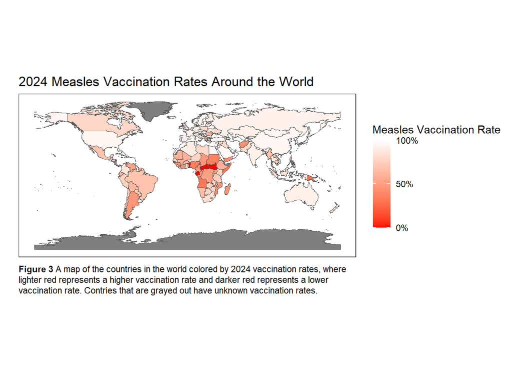

```r
world <- ne_countries(scale = "medium", returnclass = "sf")

metadata_2024 <- metadata |>
  filter(year == 2024)

world |>
  left_join(metadata_2024, join_by(iso_a3_eh == iso3)) |>
  ggplot() +
  geom_sf(aes(fill = mcv2)) +
  scale_fill_gradient(low = "red",
                      high = "white",
                      limits = c(0, 1),
                      breaks = c(0, 0.5, 1),
                      labels = label_percent()) +
  labs(title = "2024 Measles Vaccination Rates Around the World",
       x = "",
       y = "",
       fill = "Measles Vaccination Rate",
       caption = md("**Figure 3** A map of the countries in the world colored by 2024 vaccination rates, where lighter red represents a higher vaccination rate and darker red represents a lower vaccination rate. Contries that are grayed out have unknown vaccination rates."),
       alt = "A world map displaying 2024 measles vaccination rates on a red color scale. Many countries in North America, Europe, and parts of Asia appear lighter, suggesting higher vaccination coverage, while several countries in central and sub-Saharan Africa are darker, suggesting lower coverage. Some countries are gray, representing unknown vaccination rates.") +
  theme_bw() +
  theme(plot.caption = element_textbox_simple(),
        axis.text = element_blank(),
        axis.ticks = element_blank(),
        panel.grid = element_blank())
```

## Footnotes

[^1]: https://www.who.int/news-room/fact-sheets/detail/measles
[^2]: https://www.mayoclinic.org/diseases-conditions/rubella/symptoms-causes/syc-20377310
[^3]: https://www.ncbi.nlm.nih.gov/books/NBK554450/
[^4]: https://pmc.ncbi.nlm.nih.gov/articles/PMC11359298/